# Practical machine learning project

Swensy Jangal

20 février 2018

# Executive summary

The goal of this exercise is to predict if people well perform weight lifting exercises.

# Getting and cleaning data

Here is the code to get the data into the working directory :

```r
#trainingUrl <- "https://d396qusza40orc.cloudfront.net/predmachlearn/pml-training.csv"
#testUrl <- "https://d396qusza40orc.cloudfront.net/predmachlearn/pml-testing.csv"

#download.file(trainingUrl, destfile = "./training.csv")
#download.file(testUrl, destfile = "./testing.csv")

training <- read.csv("training.csv")
testing <- read.csv("testing.csv")
```

Let’s look at the data :

```r
str(training)
```

[output not shown]

The best description of the data is done in the chapter five : Detection of mistakes (see)< http://web.archive.org/web/20161224072740/http:/groupware.les.inf.puc-rio.br/har>.

The goal of this exercise is to predict if people well perform weight lifting exercises. I first select the variables that seem more relevant to me. As we’re not trying to forecast practice, I will get rid of time variables. Let’s keep the data corresponding to the gyroscope, the magnetometer, the acceleration and the Euler angles (roll, pitch and yaw) :

```r
library(dplyr)
data <- cbind(select(training, starts_with("roll_")),
              select(training, starts_with("pitch_")),
              select(training, starts_with("yaw_")),
              select(training, starts_with("gyros_")),
              select(training, starts_with("accel_")),
              select(training, starts_with("magnet_")),
              select(training, starts_with("class")))
```

# Data slicing

```r
library(caret)
inTrain <- createDataPartition(y=data$classe, p=0.7, list=FALSE)
training2 <- data[inTrain,]
testing2 <- data[-inTrain,]

remove(data)
```

# Exploratory analysis

To avoid too many predictors, we will use PCA to explain as much variance as possible. We first look at the correlation between predictors, excluding the output :

```r
M <- abs(cor(training2[,-49]))
diag(M) <- 0
which(M > 0.9,arr.ind=T)
```

```
##                  row col
## accel_belt_y      26   1
## accel_belt_z      27   1
## accel_belt_x      25   5
## gyros_arm_y       17  16
## gyros_arm_x       16  17
## gyros_dumbbell_z  21  19
## gyros_forearm_z   24  19
## gyros_dumbbell_x  19  21
## gyros_forearm_z   24  21
## gyros_dumbbell_x  19  24
## gyros_dumbbell_z  21  24
## pitch_belt         5  25
## roll_belt          1  26
## accel_belt_z      27  26
## roll_belt          1  27
## accel_belt_y      26  27
```

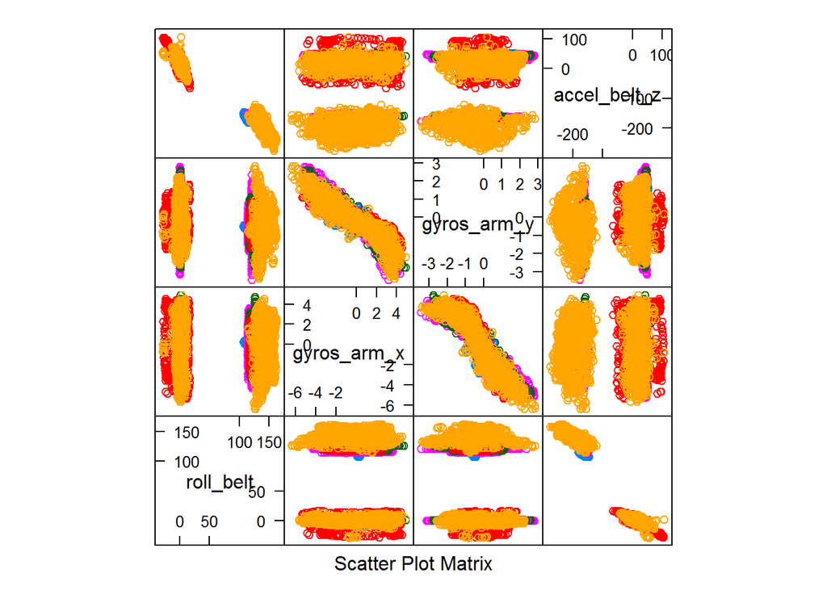

```r
featurePlot(x=training2[,c(1, 16, 17, 27)],
            y = training2$classe,
            plot="pairs")
```

# Preprocess

I will use the Principal Component method to extract the best possible combination :

```r
# preProc <- preProcess(training2[,c(1, 5, 16, 17, 19, 21, 24, 25, 26, 27)],method="pca",pcaComp=9)
preProc <- preProcess(training2[,-49],method="pca",pcaComp=2)
#summary(preProc)
```

# Fit

```r
trainPC <- predict(preProc,training2)
modelFit <- train(classe ~ .,method="rpart",data=trainPC)
```

Ici, rpart est le package de R qui permet de faire de la régression et des arbres de classification : On me montre quels sont les noeuds, comment ils se séparent et la probabilité d’être dans chaque classe pour chaque séparation.

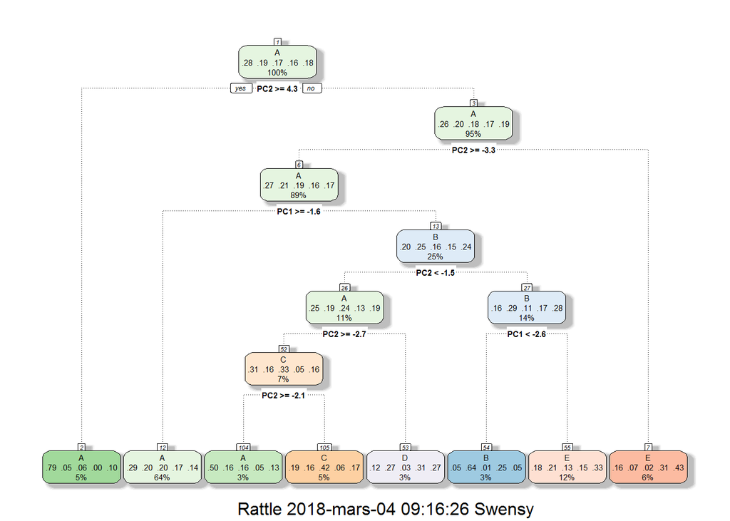

```r
library(rattle)
fancyRpartPlot(modelFit$finalModel)
```

# Prediction

```r
testPC <- predict(preProc,testing2)
confusionMatrix(testing2$classe,predict(modelFit,testPC))
```

```
## Confusion Matrix and Statistics
##
##           Reference
## Prediction    A    B    C    D    E
##          A 1397    6   46   26  199
##          B  802  103   43   35  156
##          C  809    1  105   11  100
##          D  643   39   11   52  219
##          E  563   12   54   36  417
##
## Overall Statistics
##
##                Accuracy : 0.3524
##                  95% CI : (0.3402, 0.3648)
##     No Information Rate : 0.7161
##     P-Value [Acc > NIR] : 1
##
##                   Kappa : 0.1305
##  Mcnemar's Test P-Value : <2e-16
##
## Statistics by Class:
##
##                      Class: A Class: B Class: C Class: D Class: E
## Sensitivity            0.3315  0.63975  0.40541 0.325000  0.38222
## Specificity            0.8342  0.81901  0.83630 0.840699  0.86128
## Pos Pred Value         0.8345  0.09043  0.10234 0.053942  0.38540
## Neg Pred Value         0.3310  0.98778  0.96831 0.978053  0.85967
## Prevalence             0.7161  0.02736  0.04401 0.027188  0.18539
## Detection Rate         0.2374  0.01750  0.01784 0.008836  0.07086
## Detection Prevalence   0.2845  0.19354  0.17434 0.163806  0.18386
## Balanced Accuracy      0.5829  0.72938  0.62085 0.582849  0.62175
```

# Ideas

To determine case A :

```r
# qplot(gyros_arm_y,colour=classe,data=training2,geom="density")
# qplot(gyros_arm_x,colour=classe,data=training2,geom="density")
# qplot(gyros_arm_z,colour=classe,data=training2,geom="density")
# qplot(gyros_forearm_y,colour=classe,data=training2,geom="density")
#
# # D
# qplot(magnet_forearm_x,colour=classe,data=training2,geom="density")
#
# # C
# qplot(magnet_forearm_y,colour=classe,data=training2,geom="density")

# p1 <- qplot(classe,gyros_arm_y, data=training2,fill=classe,
#       geom=c("boxplot"))
# p1

#names(training2)[c(26,1)]
#plot(training2[,26],training2[,1])

# smallSpam <- training2[,c(16,17)]
# prComp <- prcomp(smallSpam)
# plot(prComp$x[,1],prComp$x[,2])
# prComp$rotation
#
# typeColor <- ((training2$classe=="A")*1 + 1)
# prComp <- prcomp(training2[,-49])
# plot(prComp$x[,1],prComp$x[,2],col=typeColor,xlab="PC1",ylab="PC2")

# preProc$rotation
#
#

# pca <- prcomp(training2[,c(1, 5, 16, 17)], scale = TRUE)
# summary(pca)


#predictions <- predict(modelFit,newdata=testing2)
#predictions
#table(predictions, testing2$classe)
#confusionMatrix(predictions,testing2$classe)
```